# Session 1: Introduction to R and the Tidyverse

David Zimmermann

2018-09-03

```r
# For each day have a separate script and separate project in which you answer the exercises.
# Always comment your code to help your future self understand what you do!
```

# dplyr

## Data Manipulation

1. Load the tidyverse and nycflights13 and use `glimpse()` to look at the `flights` data

```r
library(tidyverse)
library(nycflights13)
flights %>% glimpse()
```

```
## Observations: 336,776
## Variables: 19
## $ year           <int> 2013, 2013, 2013, 2013, 2013, 2013, 2013, 2013,...
## $ month          <int> 1, 1, 1, 1, 1, 1, 1, 1, 1, 1, 1, 1, 1, 1, 1, 1,...
## $ day            <int> 1, 1, 1, 1, 1, 1, 1, 1, 1, 1, 1, 1, 1, 1, 1, 1,...
## $ dep_time       <int> 517, 533, 542, 544, 554, 554, 555, 557, 557, 55...
## $ sched_dep_time <int> 515, 529, 540, 545, 600, 558, 600, 600, 600, 60...
## $ dep_delay      <dbl> 2, 4, 2, -1, -6, -4, -5, -3, -3, -2, -2, -2, -2...
## $ arr_time       <int> 830, 850, 923, 1004, 812, 740, 913, 709, 838, 7...
## $ sched_arr_time <int> 819, 830, 850, 1022, 837, 728, 854, 723, 846, 7...
## $ arr_delay      <dbl> 11, 20, 33, -18, -25, 12, 19, -14, -8, 8, -2, -...
## $ carrier        <chr> "UA", "UA", "AA", "B6", "DL", "UA", "B6", "EV",...
## $ flight         <int> 1545, 1714, 1141, 725, 461, 1696, 507, 5708, 79...
## $ tailnum        <chr> "N14228", "N24211", "N619AA", "N804JB", "N668DN...
## $ origin         <chr> "EWR", "LGA", "JFK", "JFK", "LGA", "EWR", "EWR"...
## $ dest           <chr> "IAH", "IAH", "MIA", "BQN", "ATL", "ORD", "FLL"...
## $ air_time       <dbl> 227, 227, 160, 183, 116, 150, 158, 53, 140, 138...
## $ distance       <dbl> 1400, 1416, 1089, 1576, 762, 719, 1065, 229, 94...
## $ hour           <dbl> 5, 5, 5, 5, 6, 5, 6, 6, 6, 6, 6, 6, 6, 6, 6, 5,...
## $ minute         <dbl> 15, 29, 40, 45, 0, 58, 0, 0, 0, 0, 0, 0, 0, 0, ...
## $ time_hour      <dttm> 2013-01-01 05:00:00, 2013-01-01 05:00:00, 2013...
```

2. Discuss with your neighbor what the following function do: `filter`, `arrange` + `desc`, `select`, `rename`, `mutate`, `mutate_if`, `mutate_at`, `transmute`, `summarise`, `summarise_if`, `summarise_at`, `group_by`, `slice`
3. Which 7 carriers had the highest median arrival delay?

```r
flights %>%
  filter(!is.na(arr_delay)) %>%
  group_by(carrier) %>%
  summarise(median_arr_delay = median(arr_delay)) %>%
  arrange(desc(median_arr_delay)) %>%
  slice(1:7)
```

```
## # A tibble: 7 x 2
##   carrier median_arr_delay
##   <chr>              <dbl>
## 1 F9                     6
## 2 FL                     5
## 3 EV                    -1
## 4 MQ                    -1
## 5 YV                    -2
## 6 B6                    -3
## 7 WN                    -3
```

4. Sort all flights by their departure delay, relative to the mean departure delay of the respective origin airport.

```r
flights %>%
  filter(!is.na(dep_delay)) %>%
  group_by(origin) %>%
  transmute(rel_dep_delay = dep_delay - mean(dep_delay)) %>%
  arrange(desc(rel_dep_delay))
```

```
## # A tibble: 328,521 x 2
## # Groups:   origin [3]
##    origin rel_dep_delay
##    <chr>          <dbl>
##  1 JFK            1289.
##  2 JFK            1125.
##  3 EWR            1111.
##  4 JFK            1002.
##  5 JFK             993.
##  6 JFK             948.
##  7 LGA             901.
##  8 LGA             888.
##  9 JFK             887.
## 10 EWR             881.
## # ... with 328,511 more rows
```

5. Look at the `starwars` data (loaded with the tidyverse)
- Create a count of the haircolors of the characters, which color appears most often?

```r
starwars %>%
  count(hair_color, sort = T)
```

```
## # A tibble: 13 x 2
##    hair_color        n
##    <chr>         <int>
##  1 none             37
##  2 brown            18
##  3 black            13
##  4 <NA>              5
##  5 white             4
##  6 blond             3
##  7 auburn            1
##  8 auburn, grey      1
##  9 auburn, white     1
## 10 blonde            1
## 11 brown, grey       1
## 12 grey              1
## 13 unknown           1
```

- Look at the function `unnest` and `strsplit` and try to tidy the haircolors.

```r
starwars %>%
  mutate(hair_color = strsplit(hair_color, ", ")) %>%
  unnest(hair_color) %>%
  count(hair_color, sort = T)
```

```
## # A tibble: 10 x 2
##    hair_color     n
##    <chr>      <int>
##  1 none          37
##  2 brown         19
##  3 black         13
##  4 white          5
##  5 <NA>           5
##  6 auburn         3
##  7 blond          3
##  8 grey           3
##  9 blonde         1
## 10 unknown        1
```

- Who is the tallest character that is born on tatooine?

```r
starwars %>%
  filter(homeworld == "Tatooine") %>%
  arrange(desc(height)) %>%
  slice(1)
```

```
## # A tibble: 1 x 13
##   name      height  mass hair_color skin_color eye_color birth_year gender
##   <chr>      <int> <dbl> <chr>      <chr>      <chr>          <dbl> <chr>
## 1 Darth Va…    202   136 none       white      yellow          41.9 male
## # ... with 5 more variables: homeworld <chr>, species <chr>, films <list>,
## #   vehicles <list>, starships <list>
```

- Which character has the highest amount of movie appearances?

```r
starwars %>%
  unnest(films) %>%
  group_by(name) %>%
  tally(sort = T)
```

```
## # A tibble: 87 x 2
##    name               n
##    <chr>          <int>
##  1 R2-D2              7
##  2 C-3PO              6
##  3 Obi-Wan Kenobi     6
##  4 Chewbacca          5
##  5 Leia Organa        5
##  6 Luke Skywalker     5
##  7 Palpatine          5
##  8 Yoda               5
##  9 Darth Vader        4
## 10 Han Solo           4
## # ... with 77 more rows
```

```r
# alternative using map
starwars %>%
  transmute(name, n_films = map_dbl(films, length)) %>%
  arrange(desc(n_films))
```

```
## # A tibble: 87 x 2
##    name           n_films
##    <chr>            <dbl>
##  1 R2-D2                7
##  2 C-3PO                6
##  3 Obi-Wan Kenobi       6
##  4 Luke Skywalker       5
##  5 Leia Organa          5
##  6 Chewbacca            5
##  7 Yoda                 5
##  8 Palpatine            5
##  9 Darth Vader          4
## 10 Han Solo             4
## # ... with 77 more rows
```

- Which character has the highest amount of vehicles?

```r
starwars %>%
  unnest(vehicles) %>%
  group_by(name) %>%
  tally(sort = T)
```

```
## # A tibble: 11 x 2
##    name                 n
##    <chr>            <int>
##  1 Anakin Skywalker     2
##  2 Luke Skywalker       2
##  3 Chewbacca            1
##  4 Darth Maul           1
##  5 Dooku                1
##  6 Grievous             1
##  7 Leia Organa          1
##  8 Obi-Wan Kenobi       1
##  9 Qui-Gon Jinn         1
## 10 Wedge Antilles       1
## 11 Zam Wesell           1
```

- Create for each movie a list of characters that appear.

```r
starwars %>%
  unnest(films) %>%
  select(name, films) %>%
  mutate(value = 1) %>%
  spread(key = "films", value = "value", fill = 0)
```

```
## # A tibble: 87 x 8
##    name   `A New Hope` `Attack of the C… `Return of the … `Revenge of the…
##    <chr>         <dbl>             <dbl>            <dbl>            <dbl>
##  1 Ackbar            0                 0                1                0
##  2 Adi G…            0                 0                0                1
##  3 Anaki…            0                 1                0                1
##  4 Arvel…            0                 0                1                0
##  5 Ayla …            0                 1                0                1
##  6 Bail …            0                 1                0                1
##  7 Barri…            0                 1                0                0
##  8 BB8               0                 0                0                0
##  9 Ben Q…            0                 0                0                0
## 10 Beru …            1                 1                0                1
## # ... with 77 more rows, and 3 more variables: `The Empire Strikes
## #   Back` <dbl>, `The Force Awakens` <dbl>, `The Phantom Menace` <dbl>
```

## Joins

1. Which aircraft manufacturer had the highest number of flights?

```r
left_join(flights,
          planes %>% select(tailnum, manufacturer),
          by = "tailnum") %>%
  group_by(manufacturer) %>%
  tally(sort = T)
```

```
## # A tibble: 36 x 2
##    manufacturer                      n
##    <chr>                         <int>
##  1 BOEING                        82912
##  2 EMBRAER                       66068
##  3 <NA>                          52606
##  4 AIRBUS                        47302
##  5 AIRBUS INDUSTRIE              40891
##  6 BOMBARDIER INC                28272
##  7 MCDONNELL DOUGLAS AIRCRAFT CO  8932
##  8 MCDONNELL DOUGLAS              3998
##  9 CANADAIR                       1594
## 10 MCDONNELL DOUGLAS CORPORATION  1259
## # ... with 26 more rows
```

```r
# use `case_when()` to replace certain values only
left_join(flights,
          planes %>% select(tailnum, manufacturer),
          by = "tailnum") %>%
  mutate(manufacturer = case_when(
    manufacturer == "AIRBUS INDUSTRIE" ~ "AIRBUS",
    manufacturer == "MCDONNELL DOUGLAS AIRCRAFT CO" ~ "MCDONNELL DOUGLAS",
    manufacturer == "MCDONNELL DOUGLAS CORPORATION" ~ "MCDONNELL DOUGLAS",
    TRUE ~ manufacturer
  )) %>%
  group_by(manufacturer) %>%
  tally(sort = T)
```

```
## # A tibble: 33 x 2
##    manufacturer             n
##    <chr>                <int>
##  1 AIRBUS               88193
##  2 BOEING               82912
##  3 EMBRAER              66068
##  4 <NA>                 52606
##  5 BOMBARDIER INC       28272
##  6 MCDONNELL DOUGLAS    14189
##  7 CANADAIR              1594
##  8 CESSNA                 658
##  9 GULFSTREAM AEROSPACE   499
## 10 CIRRUS DESIGN CORP     291
## # ... with 23 more rows
```

2. Which model had the highest number of flights?

```r
left_join(flights,
          planes %>% select(tailnum, model),
          by = "tailnum") %>%
  group_by(model) %>%
  tally(sort = T)
```

```
## # A tibble: 128 x 2
##    model               n
##    <chr>           <int>
##  1 <NA>            52606
##  2 A320-232        45831
##  3 EMB-145LR       28027
##  4 ERJ 190-100 IGW 23716
##  5 EMB-145XR       14051
##  6 737-824         13809
##  7 CL-600-2D24     11807
##  8 737-7H4         10389
##  9 MD-88           10191
## 10 A319-114         9713
## # ... with 118 more rows
```

3. Is there a correlation between departure delay and wind speed?

```r
flights_weather <- left_join(flights,
                             weather %>% select(origin, time_hour, wind_dir, wind_speed),
                             by = c("origin", "time_hour")) %>%
  filter(!is.na(dep_delay), !is.na(wind_speed))

cor(flights_weather$dep_delay, flights_weather$wind_speed)
```

```
## [1] 0.04742427
```

4. Are all destination airports in the airports dataset and vice versa? Which are missing?

```r
# are all flights in airports?
anti_join(flights, airports, by = c("origin" = "faa"))%>% count(origin)
```

```
## # A tibble: 0 x 2
## # ... with 2 variables: origin <chr>, n <int>
```

```r
anti_join(flights, airports, by = c("dest" = "faa")) %>% count(dest)
```

```
## # A tibble: 4 x 2
##   dest      n
##   <chr> <int>
## 1 BQN     896
## 2 PSE     365
## 3 SJU    5819
## 4 STT     522
```

```r
# are all airports in flights?
anti_join(airports, flights, by = c("faa" = "origin"))%>% count(faa)
```

```
## # A tibble: 1,455 x 2
##    faa       n
##    <chr> <int>
##  1 04G       1
##  2 06A       1
##  3 06C       1
##  4 06N       1
##  5 09J       1
##  6 0A9       1
##  7 0G6       1
##  8 0G7       1
##  9 0P2       1
## 10 0S9       1
## # ... with 1,445 more rows
```

```r
anti_join(airports, flights, by = c("faa" = "dest"))%>% count(faa)
```

```
## # A tibble: 1,357 x 2
##    faa       n
##    <chr> <int>
##  1 04G       1
##  2 06A       1
##  3 06C       1
##  4 06N       1
##  5 09J       1
##  6 0A9       1
##  7 0G6       1
##  8 0G7       1
##  9 0P2       1
## 10 0S9       1
## # ... with 1,347 more rows
```

# purrr

1. Use the GOT characters and find the character that has the highest amount of titles.

```r
library(repurrrsive)

vec <- map(got_chars, "titles") %>%
  set_names(map(got_chars, "name")) %>%
  map_dbl(function(x) length(x[x != ""]))

vec[vec == max(vec)]
```

```
## Daenerys Targaryen   Cersei Lannister       Eddard Stark
##                  5                  5                  5
```

```r
# more compact
map(got_chars, "titles") %>%
  set_names(map(got_chars, "name")) %>%
  map_dbl(function(x) length(x[x != ""])) %>%
  {.[. == max(.)]}
```

```
## Daenerys Targaryen   Cersei Lannister       Eddard Stark
##                  5                  5                  5
```

```r
# alternative
map(got_chars, "titles") %>%
  set_names(map(got_chars, "name")) %>%
  map_dbl(~length(.x[.x != ""]))
```

```
##      Theon Greyjoy   Tyrion Lannister  Victarion Greyjoy
##                  3                  2                  2
##               Will         Areo Hotah              Chett
##                  0                  1                  0
##            Cressen    Arianne Martell Daenerys Targaryen
##                  1                  1                  5
##     Davos Seaworth         Arya Stark      Arys Oakheart
##                  4                  1                  1
##       Asha Greyjoy    Barristan Selmy            Varamyr
##                  3                  2                  0
##      Brandon Stark   Brienne of Tarth      Catelyn Stark
##                  1                  0                  1
##   Cersei Lannister       Eddard Stark    Jaime Lannister
##                  5                  5                  3
##     Jon Connington           Jon Snow      Aeron Greyjoy
##                  3                  1                  2
##    Kevan Lannister         Melisandre       Merrett Frey
##                  4                  0                  0
##    Quentyn Martell      Samwell Tarly        Sansa Stark
##                  1                  0                  1
```

```r
# alternative
length_non_empty <- function(x) length(x[x != ""])
map(got_chars, "titles") %>%
  set_names(map(got_chars, "name")) %>%
  map_dbl(length_non_empty)
```

```
##      Theon Greyjoy   Tyrion Lannister  Victarion Greyjoy
##                  3                  2                  2
##               Will         Areo Hotah              Chett
##                  0                  1                  0
##            Cressen    Arianne Martell Daenerys Targaryen
##                  1                  1                  5
##     Davos Seaworth         Arya Stark      Arys Oakheart
##                  4                  1                  1
##       Asha Greyjoy    Barristan Selmy            Varamyr
##                  3                  2                  0
##      Brandon Stark   Brienne of Tarth      Catelyn Stark
##                  1                  0                  1
##   Cersei Lannister       Eddard Stark    Jaime Lannister
##                  5                  5                  3
##     Jon Connington           Jon Snow      Aeron Greyjoy
##                  3                  1                  2
##    Kevan Lannister         Melisandre       Merrett Frey
##                  4                  0                  0
##    Quentyn Martell      Samwell Tarly        Sansa Stark
##                  1                  0                  1
```

2. What are the characters with the highest number of allegiances, tv appearances, and book appearances.

```r
map(got_chars, "allegiances") %>%
  set_names(map(got_chars, "name")) %>%
  map_dbl(function(x) length(x[x != ""])) %>%
  {.[. == max(.)]}
```

```
## Brienne of Tarth
##                3
```

3. Create a data-frame in the tidy format that contains the name-actor/actress combinations.

```r
map_dfr(got_chars, function(x) as_data_frame(x[c("name", "playedBy")]))
```

```
## # A tibble: 32 x 2
##    name               playedBy
##    <chr>              <chr>
##  1 Theon Greyjoy      Alfie Allen
##  2 Tyrion Lannister   Peter Dinklage
##  3 Victarion Greyjoy  ""
##  4 Will               Bronson Webb
##  5 Areo Hotah         DeObia Oparei
##  6 Chett              ""
##  7 Cressen            Oliver Ford
##  8 Arianne Martell    ""
##  9 Daenerys Targaryen Emilia Clarke
## 10 Davos Seaworth     Liam Cunningham
## # ... with 22 more rows
```

```r
map_dfr(got_chars, ~as_data_frame(.x[c("name", "playedBy")])) %>%
  mutate(playedBy = ifelse(playedBy == "", NA, playedBy))
```

```
## # A tibble: 32 x 2
##    name               playedBy
##    <chr>              <chr>
##  1 Theon Greyjoy      Alfie Allen
##  2 Tyrion Lannister   Peter Dinklage
##  3 Victarion Greyjoy  <NA>
##  4 Will               Bronson Webb
##  5 Areo Hotah         DeObia Oparei
##  6 Chett              <NA>
##  7 Cressen            Oliver Ford
##  8 Arianne Martell    <NA>
##  9 Daenerys Targaryen Emilia Clarke
## 10 Davos Seaworth     Liam Cunningham
## # ... with 22 more rows
```

```r
# alternative if all variables have the same length (doesnt work with playedBy but with born)
map_dfr(got_chars, `[`, c("name", "born"))
```

```
## # A tibble: 30 x 2
##    name               born
##    <chr>              <chr>
##  1 Theon Greyjoy      In 278 AC or 279 AC, at Pyke
##  2 Tyrion Lannister   In 273 AC, at Casterly Rock
##  3 Victarion Greyjoy  In 268 AC or before, at Pyke
##  4 Will               ""
##  5 Areo Hotah         In 257 AC or before, at Norvos
##  6 Chett              At Hag's Mire
##  7 Cressen            In 219 AC or 220 AC
##  8 Arianne Martell    In 276 AC, at Sunspear
##  9 Daenerys Targaryen In 284 AC, at Dragonstone
## 10 Davos Seaworth     In 260 AC or before, at King's Landing
## # ... with 20 more rows
```

```r
# map(1:3, `+`, 2)
```

4. Reshape the earlier name-actor/actress dataset into an encoded dataset (i.e., rows are the names, columns are the actor/actress, the values are T/F or 1/0).

```r
df <- map_dfr(got_chars, function(x) as_data_frame(x[c("name", "playedBy")]))

actor_char_map <- df %>%
  mutate(
    playedBy = ifelse(playedBy == "", NA, playedBy),
    value = 1
  ) %>%
  spread(key = "name", value = "value", fill = 0)

actor_char_map
```

```
## # A tibble: 25 x 31
##    playedBy     `Aeron Greyjoy` `Areo Hotah` `Arianne Martel… `Arya Stark`
##    <chr>                  <dbl>        <dbl>            <dbl>        <dbl>
##  1 Alfie Allen                0            0                0            0
##  2 Bronson Webb               0            0                0            0
##  3 Carice van …               0            0                0            0
##  4 DeObia Opar…               0            1                0            0
##  5 Emilia Clar…               0            0                0            0
##  6 Gemma Whelan               0            0                0            0
##  7 Gwendoline …               0            0                0            0
##  8 Ian Gelder                 0            0                0            0
##  9 Ian McElhin…               0            0                0            0
## 10 Isaac Hemps…               0            0                0            0
## # ... with 15 more rows, and 26 more variables: `Arys Oakheart` <dbl>,
## #   `Asha Greyjoy` <dbl>, `Barristan Selmy` <dbl>, `Brandon Stark` <dbl>,
## #   `Brienne of Tarth` <dbl>, `Catelyn Stark` <dbl>, `Cersei
## #   Lannister` <dbl>, Chett <dbl>, Cressen <dbl>, `Daenerys
## #   Targaryen` <dbl>, `Davos Seaworth` <dbl>, `Eddard Stark` <dbl>, `Jaime
## #   Lannister` <dbl>, `Jon Connington` <dbl>, `Jon Snow` <dbl>, `Kevan
## #   Lannister` <dbl>, Melisandre <dbl>, `Merrett Frey` <dbl>, `Quentyn
## #   Martell` <dbl>, `Samwell Tarly` <dbl>, `Sansa Stark` <dbl>, `Theon
## #   Greyjoy` <dbl>, `Tyrion Lannister` <dbl>, Varamyr <dbl>, `Victarion
## #   Greyjoy` <dbl>, Will <dbl>
```

5. Use the online dataset of all GOT characters from https://anapioficeandfire.com and https://github.com/joakimskoog/AnApiOfIceAndFire/tree/master/data (hint `jsonlite::fromJSON()`) and repeat the exercises from before.

```r
house_url <- "https://raw.githubusercontent.com/joakimskoog/AnApiOfIceAndFire/master/data/houses.json"

library(jsonlite)
got_houses <- read_json(house_url)
map_chr(got_houses, "Name") %>% head()
```

```
## [1] "House Algood"                "House Allyrion of Godsgrace"
## [3] "House Amber"                 "House Ambrose"
## [5] "House Appleton of Appleton"  "House Arryn of Gulltown"
```

```r
got_houses[[1]] %>% names()
```

```
##  [1] "Id"               "Name"             "Seats"
##  [4] "Region"           "CoatOfArms"       "Words"
##  [7] "Titles"           "CurrentLord"      "Founder"
## [10] "Founded"          "Heir"             "Overlord"
## [13] "DiedOut"          "AncestralWeapons" "CadetBranches"
```

```r
# region-house
map_dfr(got_houses, function(x) as_data_frame(x[c("Name", "Region")]))
```

```
## # A tibble: 444 x 2
##    Name                        Region
##    <chr>                       <chr>
##  1 House Algood                The Westerlands
##  2 House Allyrion of Godsgrace Dorne
##  3 House Amber                 The North
##  4 House Ambrose               The Reach
##  5 House Appleton of Appleton  The Reach
##  6 House Arryn of Gulltown     The Vale
##  7 House Arryn of the Eyrie    The Vale
##  8 House Ashford of Ashford    The Reach
##  9 House Ashwood               The North
## 10 House Baelish of Harrenhal  The Riverlands
## # ... with 434 more rows
```

```r
map_dfr(got_houses, ~as_data_frame(.x[c("Name", "Region")]))
```

```
## # A tibble: 444 x 2
##    Name                        Region
##    <chr>                       <chr>
##  1 House Algood                The Westerlands
##  2 House Allyrion of Godsgrace Dorne
##  3 House Amber                 The North
##  4 House Ambrose               The Reach
##  5 House Appleton of Appleton  The Reach
##  6 House Arryn of Gulltown     The Vale
##  7 House Arryn of the Eyrie    The Vale
##  8 House Ashford of Ashford    The Reach
##  9 House Ashwood               The North
## 10 House Baelish of Harrenhal  The Riverlands
## # ... with 434 more rows
```

```r
map_dfr(got_houses, ~as_data_frame(.x[c("Name", "Region")])) %>%
  group_by(Region) %>%
  tally() %>%
  arrange(n)
```

```
## # A tibble: 13 x 2
##    Region              n
##    <chr>           <int>
##  1 Beyond the Wall     1
##  2 None                1
##  3 ""                  6
##  4 The Neck            7
##  5 Dorne              29
##  6 The Vale           35
##  7 Iron Islands       38
##  8 The Stormlands     38
##  9 The Crownlands     49
## 10 The Riverlands     52
## 11 The Westerlands    55
## 12 The North          61
## 13 The Reach          72
```

```r
# map_dfr(got_houses, ~as_data_frame(.x[c("Name", "Region")])) %>%
#   filter(Region == "Beyond the Wall")
```

```r
library(nycflights13)
flights %>% sample_n(10)
```

```
## # A tibble: 10 x 19
##     year month   day dep_time sched_dep_time dep_delay arr_time
##    <int> <int> <int>    <int>          <int>     <dbl>    <int>
##  1  2013     6    19     1654           1700        -6     1812
##  2  2013     9    19     1035           1045       -10     1204
##  3  2013    10    29     1536           1545        -9     1715
##  4  2013     5    16     1721           1710        11     1938
##  5  2013     6     8      804            755         9      955
##  6  2013     5     1     1053           1100        -7     1154
##  7  2013     3    23      815            815         0     1118
##  8  2013     3    17     1743           1745        -2     2029
##  9  2013     3    29      554            600        -6      832
## 10  2013     2     4     1349           1220        89     1516
## # ... with 12 more variables: sched_arr_time <int>, arr_delay <dbl>,
## #   carrier <chr>, flight <int>, tailnum <chr>, origin <chr>, dest <chr>,
## #   air_time <dbl>, distance <dbl>, hour <dbl>, minute <dbl>,
## #   time_hour <dttm>
```

```r
flights %>% sample_frac(0.01)
```

```
## # A tibble: 3,368 x 19
##     year month   day dep_time sched_dep_time dep_delay arr_time
##    <int> <int> <int>    <int>          <int>     <dbl>    <int>
##  1  2013    11    20      616            620        -4      802
##  2  2013    10     7     1351           1359        -8     1546
##  3  2013    12     6      720            727        -7      956
##  4  2013     7    25     2233           2110        83       33
##  5  2013     6    14     2101           2055         6        5
##  6  2013     3    13      626            630        -4      828
##  7  2013     6    17     1732           1550       102     2029
##  8  2013     1    11     1325           1330        -5     1605
##  9  2013     2    19      831            836        -5     1114
## 10  2013     7    25     1125           1130        -5     1339
## # ... with 3,358 more rows, and 12 more variables: sched_arr_time <int>,
## #   arr_delay <dbl>, carrier <chr>, flight <int>, tailnum <chr>,
## #   origin <chr>, dest <chr>, air_time <dbl>, distance <dbl>, hour <dbl>,
## #   minute <dbl>, time_hour <dttm>
```

```r
flights2 <- flights %>% filter(!is.na(arr_delay))

# make the randomness reproducible
set.seed(201809045)
mean_df <- map_dfr(1:100, function(i) {
  flights2 %>%
    sample_frac(0.5) %>%
    summarise(mean = mean(arr_delay))
})

mean_df
```

```
## # A tibble: 100 x 1
##     mean
##    <dbl>
##  1  6.91
##  2  6.85
##  3  6.89
##  4  6.85
##  5  6.83
##  6  6.95
##  7  6.91
##  8  7.01
##  9  6.81
## 10  6.94
## # ... with 90 more rows
```

```r
quantile(mean_df$mean)
```

```
##       0%      25%      50%      75%     100%
## 6.685978 6.821771 6.876342 6.927065 7.074899
```

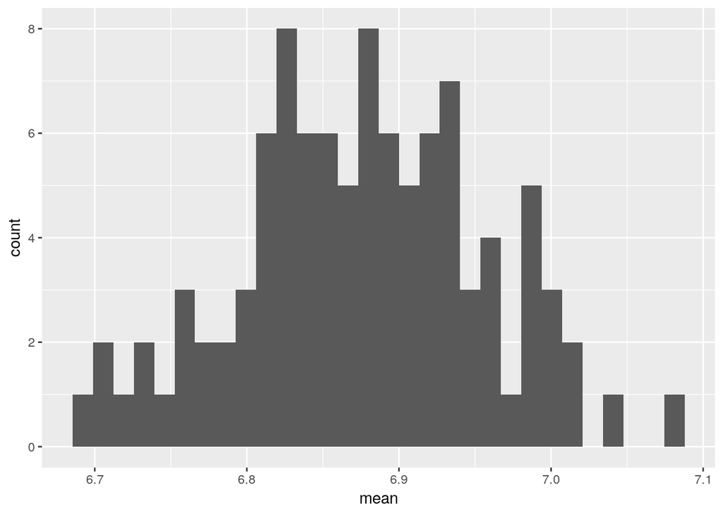

```r
ggplot(mean_df, aes(x = mean)) + geom_histogram(bins = 30)
```